# HW1 - Data Analysis

##### 負責助教：陳亮宇 catchingfire80@gmail.com

> 此次作業將讓大家確認自己的環境是否安裝成功，  
> 以及 Numpy / Scikit-Learn / Matplotlib 的基本使用

## 評分標準

- 上課繳交：25%
  - 在當天 16:20 前上傳至 new E3 作業，請將以下打包成 .zip 上傳：
    - 程式原始檔 (.ipynb）
    - 程式 .html 檔
- 程式分數：75%
  - 於一週內完成並上傳至 new E3

#### 注意：最終學期成績將視全班原始成績做調整

## 基本資料 - 5%

#### 學號：（109705011）

## Packages that Might Be Used

```python
import sklearn
import sklearn.datasets
import numpy as np

import matplotlib.pyplot as plt
%matplotlib inline
```

### 相關連結

- Packages
  - [numpy](http://www.numpy.org/)
  - [pandas](https://pandas.pydata.org/)
  - [re](https://docs.python.org/zh-cn/3/library/re.html)
  - [CountVectorizer](https://scikit-learn.org/stable/modules/generated/sklearn.feature_extraction.text.CountVectorizer.html)
  - [LabelEncoder](https://scikit-learn.org/stable/modules/generated/sklearn.preprocessing.LabelEncoder.html)
  - [difflib](https://docs.python.org/2/library/difflib.html)
  - [train_test_split](https://scikit-learn.org/stable/modules/generated/sklearn.model_selection.train_test_split.html)
  - [DecisionTreeClassifier](https://scikit-learn.org/stable/modules/tree.html)
  - [RandomForestClassifier](https://scikit-learn.org/stable/modules/generated/sklearn.ensemble.RandomForestClassifier.html)
  - [classification_report](https://scikit-learn.org/stable/modules/generated/sklearn.metrics.classification_report.html)
  - [confusion_matrix](https://scikit-learn.org/stable/modules/generated/sklearn.metrics.confusion_matrix.html)
  - [pyplot](https://matplotlib.org/tutorials/introductory/pyplot.html)
  - [pyhotpot](https://reurl.cc/dVyqz8)
- Markdown
  - jupyter 可以支援 markdown 區塊，方便打上文字說明此份 notebook 在做的事情
  - [wiki](https://zh.wikipedia.org/wiki/Markdown)
  - [教學](https://markdown.tw/)

## Load Data

#### 請使用 `scikit-learn` 讀取 Wine Dataset - 5% - [Hint](https://scikit-learn.org/stable/modules/generated/sklearn.datasets.load_wine.html)

```python
wine = sklearn.datasets.load_wine()
wine
```

```
{'data': array([[1.423e+01, 1.710e+00, 2.430e+00, ..., 1.040e+00, 3.920e+00,
         1.065e+03],
        [1.320e+01, 1.780e+00, 2.140e+00, ..., 1.050e+00, 3.400e+00,
         1.050e+03],
        [1.316e+01, 2.360e+00, 2.670e+00, ..., 1.030e+00, 3.170e+00,
         1.185e+03],
        ...,
        [1.327e+01, 4.280e+00, 2.260e+00, ..., 5.900e-01, 1.560e+00,
         8.350e+02],
        [1.317e+01, 2.590e+00, 2.370e+00, ..., 6.000e-01, 1.620e+00,
         8.400e+02],
        [1.413e+01, 4.100e+00, 2.740e+00, ..., 6.100e-01, 1.600e+00,
         5.600e+02]]),
 'target': array([0, 0, 0, 0, 0, 0, 0, 0, 0, 0, 0, 0, 0, 0, 0, 0, 0, 0, 0, 0, 0, 0,
        0, 0, 0, 0, 0, 0, 0, 0, 0, 0, 0, 0, 0, 0, 0, 0, 0, 0, 0, 0, 0, 0,
        0, 0, 0, 0, 0, 0, 0, 0, 0, 0, 0, 0, 0, 0, 0, 1, 1, 1, 1, 1, 1, 1,
        1, 1, 1, 1, 1, 1, 1, 1, 1, 1, 1, 1, 1, 1, 1, 1, 1, 1, 1, 1, 1, 1,
        1, 1, 1, 1, 1, 1, 1, 1, 1, 1, 1, 1, 1, 1, 1, 1, 1, 1, 1, 1, 1, 1,
        1, 1, 1, 1, 1, 1, 1, 1, 1, 1, 1, 1, 1, 1, 1, 1, 1, 1, 1, 1, 2, 2,
        2, 2, 2, 2, 2, 2, 2, 2, 2, 2, 2, 2, 2, 2, 2, 2, 2, 2, 2, 2, 2, 2,
        2, 2, 2, 2, 2, 2, 2, 2, 2, 2, 2, 2, 2, 2, 2, 2, 2, 2, 2, 2, 2, 2,
        2, 2]),
 'frame': None,
 'target_names': array(['class_0', 'class_1', 'class_2'], dtype='<U7'),
 'DESCR': '.. _wine_dataset:\n\nWine recognition dataset\n------------------------\n\n**Data Set Characteristics:**\n\n    :Number of Instances: 178 (50 in each of three classes)\n    :Number of Attributes: 13 numeric, predictive attributes and the class\n    :Attribute Information:\n \t\t- Alcohol\…
 'feature_names': ['alcohol',
  'malic_acid',
  'ash',
  'alcalinity_of_ash',
  'magnesium',
  'total_phenols',
  'flavanoids',
  'nonflavanoid_phenols',
  'proanthocyanins',
  'color_intensity',
  'hue',
  'od280/od315_of_diluted_wines',
  'proline']}
```

## 問題

請簡述以下問題，將 ans 取代為你的答案 - 5%

> `wine dataset` 為一 classification（分類）問題，  
> 在一個經典的 classfication 問題中，一筆資料（又稱一 data instance）將包含以下部分：
> - feature （或叫 attribute ）部分
>   - 此筆資料的各項屬性
> - target（或叫 label）部分
>   - 此筆資料的分類

## 分析

#### 印出 `wine` 的 `data` 部分 - 5%

```python
wine['data']
```

```
array([[1.423e+01, 1.710e+00, 2.430e+00, ..., 1.040e+00, 3.920e+00,
        1.065e+03],
       [1.320e+01, 1.780e+00, 2.140e+00, ..., 1.050e+00, 3.400e+00,
        1.050e+03],
       [1.316e+01, 2.360e+00, 2.670e+00, ..., 1.030e+00, 3.170e+00,
        1.185e+03],
       ...,
       [1.327e+01, 4.280e+00, 2.260e+00, ..., 5.900e-01, 1.560e+00,
        8.350e+02],
       [1.317e+01, 2.590e+00, 2.370e+00, ..., 6.000e-01, 1.620e+00,
        8.400e+02],
       [1.413e+01, 4.100e+00, 2.740e+00, ..., 6.100e-01, 1.600e+00,
        5.600e+02]])
```

#### 印出 `wine` 的 `data` 部分的 **shape** - 5% - [hint](https://docs.scipy.org/doc/numpy/reference/generated/numpy.ndarray.shape.html)

```python
print(d.shape)
```

[output not shown]

#### 可以看出 `wine dataset` 具有 178 筆資料，而每筆資料有 13 個 features

#### 印出 `wine` 的 feature - 5%

```python
wine.feature_names
```

```
['alcohol',
 'malic_acid',
 'ash',
 'alcalinity_of_ash',
 'magnesium',
 'total_phenols',
 'flavanoids',
 'nonflavanoid_phenols',
 'proanthocyanins',
 'color_intensity',
 'hue',
 'od280/od315_of_diluted_wines',
 'proline']
```

#### 印出 `wine` 的 target (label) - 5%

```python
wine.target
```

```
array([0, 0, 0, 0, 0, 0, 0, 0, 0, 0, 0, 0, 0, 0, 0, 0, 0, 0, 0, 0, 0, 0,
       0, 0, 0, 0, 0, 0, 0, 0, 0, 0, 0, 0, 0, 0, 0, 0, 0, 0, 0, 0, 0, 0,
       0, 0, 0, 0, 0, 0, 0, 0, 0, 0, 0, 0, 0, 0, 0, 1, 1, 1, 1, 1, 1, 1,
       1, 1, 1, 1, 1, 1, 1, 1, 1, 1, 1, 1, 1, 1, 1, 1, 1, 1, 1, 1, 1, 1,
       1, 1, 1, 1, 1, 1, 1, 1, 1, 1, 1, 1, 1, 1, 1, 1, 1, 1, 1, 1, 1, 1,
       1, 1, 1, 1, 1, 1, 1, 1, 1, 1, 1, 1, 1, 1, 1, 1, 1, 1, 1, 1, 2, 2,
       2, 2, 2, 2, 2, 2, 2, 2, 2, 2, 2, 2, 2, 2, 2, 2, 2, 2, 2, 2, 2, 2,
       2, 2, 2, 2, 2, 2, 2, 2, 2, 2, 2, 2, 2, 2, 2, 2, 2, 2, 2, 2, 2, 2,
       2, 2])
```

#### 印出 `wine` 的第 39, 48, 99, 170 個 data instances （並包含其 target / label） - 10% - [Hint](https://docs.scipy.org/doc/numpy/reference/arrays.indexing.html)

Note: 格式可以稍微不同

```python
indices = [39, 48, 99, 170]
for i in indices:
    print(str(i) + "th", wine.data[i], wine.target[i])
```

```
39th [1.422e+01 3.990e+00 2.510e+00 1.320e+01 1.280e+02 3.000e+00 3.040e+00
 2.000e-01 2.080e+00 5.100e+00 8.900e-01 3.530e+00 7.600e+02] 0
48th [1.41e+01 2.02e+00 2.40e+00 1.88e+01 1.03e+02 2.75e+00 2.92e+00 3.20e-01
 2.38e+00 6.20e+00 1.07e+00 2.75e+00 1.06e+03] 0
99th [ 12.29   3.17   2.21  18.    88.     2.85   2.99   0.45   2.81   2.3
   1.42   2.83 406.  ] 1
170th [1.22e+01 3.03e+00 2.32e+00 1.90e+01 9.60e+01 1.25e+00 4.90e-01 4.00e-01
 7.30e-01 5.50e+00 6.60e-01 1.83e+00 5.10e+02] 2
```

#### 計算 `wine` 中所有 feature 的以下數值並印出： - 20%

- minimum
- maximum
- [median](https://docs.scipy.org/doc/numpy/reference/generated/numpy.median.html)
- mean
- standard deviation

```python
wine.data[:, 0]
```

```
array([14.23, 13.2 , 13.16, 14.37, 13.24, 14.2 , 14.39, 14.06, 14.83,
       13.86, 14.1 , 14.12, 13.75, 14.75, 14.38, 13.63, 14.3 , 13.83,
       14.19, 13.64, 14.06, 12.93, 13.71, 12.85, 13.5 , 13.05, 13.39,
       13.3 , 13.87, 14.02, 13.73, 13.58, 13.68, 13.76, 13.51, 13.48,
       13.28, 13.05, 13.07, 14.22, 13.56, 13.41, 13.88, 13.24, 13.05,
       14.21, 14.38, 13.9 , 14.1 , 13.94, 13.05, 13.83, 13.82, 13.77,
       13.74, 13.56, 14.22, 13.29, 13.72, 12.37, 12.33, 12.64, 13.67,
       12.37, 12.17, 12.37, 13.11, 12.37, 13.34, 12.21, 12.29, 13.86,
       13.49, 12.99, 11.96, 11.66, 13.03, 11.84, 12.33, 12.7 , 12.  ,
       12.72, 12.08, 13.05, 11.84, 12.67, 12.16, 11.65, 11.64, 12.08,
       12.08, 12.  , 12.69, 12.29, 11.62, 12.47, 11.81, 12.29, 12.37,
       12.29, 12.08, 12.6 , 12.34, 11.82, 12.51, 12.42, 12.25, 12.72,
       12.22, 11.61, 11.46, 12.52, 11.76, 11.41, 12.08, 11.03, 11.82,
       12.42, 12.77, 12.  , 11.45, 11.56, 12.42, 13.05, 11.87, 12.07,
       12.43, 11.79, 12.37, 12.04, 12.86, 12.88, 12.81, 12.7 , 12.51,
       12.6 , 12.25, 12.53, 13.49, 12.84, 12.93, 13.36, 13.52, 13.62,
       12.25, 13.16, 13.88, 12.87, 13.32, 13.08, 13.5 , 12.79, 13.11,
       13.23, 12.58, 13.17, 13.84, 12.45, 14.34, 13.48, 12.36, 13.69,
       12.85, 12.96, 13.78, 13.73, 13.45, 12.82, 13.58, 13.4 , 12.2 ,
       12.77, 14.16, 13.71, 13.4 , 13.27, 13.17, 14.13])
```

```python
for i in range(13):
    print(wine.feature_names[i])
    print(min(wine.data[:,i]), max(wine.data[:,i]), np.median(wine.data[:,i]), np.mean(wine.data[:,i]), np.std(wine.data[:,i]), sep = ', ')
    print()
```

```
alcohol
11.03, 14.83, 13.05, 13.00061797752809, 0.8095429145285168

malic_acid
0.74, 5.8, 1.8650000000000002, 2.3363483146067416, 1.1140036269797893

ash
1.36, 3.23, 2.36, 2.3665168539325845, 0.27357229442643255

alcalinity_of_ash
10.6, 30.0, 19.5, 19.49494382022472, 3.3301697576582128

magnesium
70.0, 162.0, 98.0, 99.74157303370787, 14.242307673359806

total_phenols
0.98, 3.88, 2.355, 2.295112359550562, 0.6240905641965369

flavanoids
0.34, 5.08, 2.135, 2.0292696629213487, 0.996048950379233

nonflavanoid_phenols
0.13, 0.66, 0.34, 0.3618539325842696, 0.12410325988364795

proanthocyanins
0.41, 3.58, 1.5550000000000002, 1.5908988764044945, 0.5707488486199379

color_intensity
1.28, 13.0, 4.6899999999999995, 5.058089882022472, 2.3117646609525573

hue
0.48, 1.71, 0.965, 0.9574494382022471, 0.22792860656507252

od280/od315_of_diluted_wines
1.27, 4.0, 2.78, 2.6116853932584267, 0.7079932646716005

proline
278.0, 1680.0, 673.5, 746.8932584269663, 314.0216568419878
```

## Visualization

#### 對 `alcohol`, `malic_acid`, `ash` 三個 feature，各自繪製一 scatter 圖 - 20%

- title 為其 feature 名字
- X 軸為其 target，並需對應 class_0 - class_2
- Y 軸為該 feature 在對應的 target 下的分佈
- 點需依照 target 上色，三個 target 需顏色不同

Hints:

- [pyplot.title](https://matplotlib.org/3.1.1/api/_as_gen/matplotlib.pyplot.title.html)
- [pyplot.scatter](https://matplotlib.org/3.1.1/api/_as_gen/matplotlib.pyplot.scatter.html)
- [pyplot.xticks](https://matplotlib.org/3.1.1/api/_as_gen/matplotlib.pyplot.xticks.html)

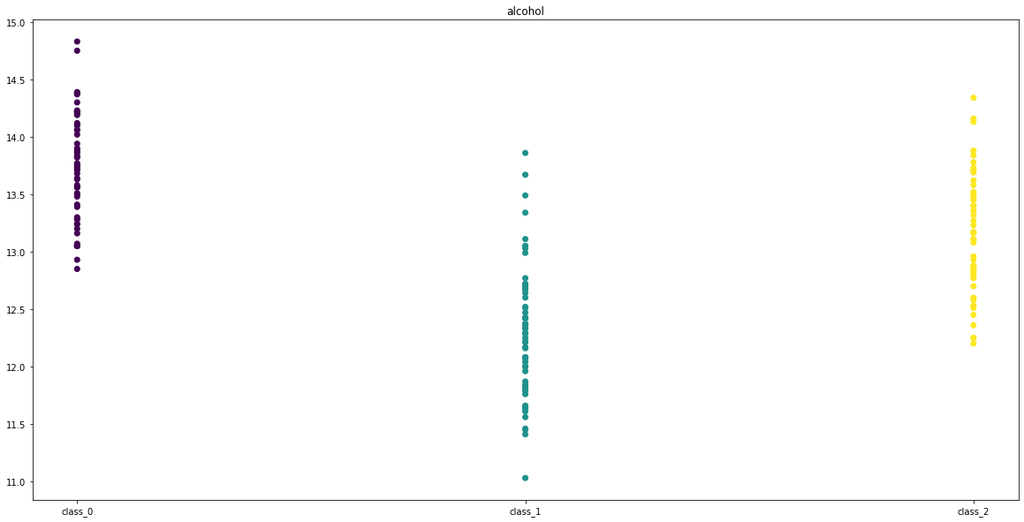

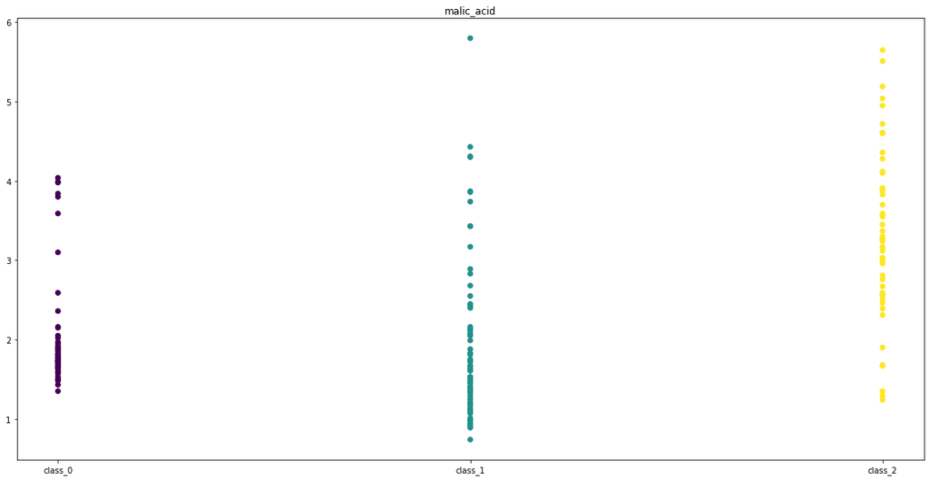

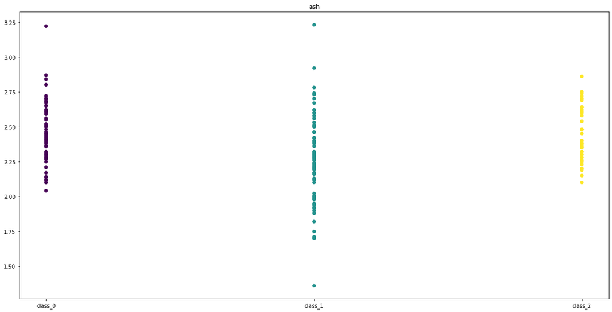

```python
for i in range(3):
    plt.figure(figsize=(20, 10)) # 讓你的圖看起來大大的
    plt.title(wine.feature_names[i], fontdict = None, loc = 'center', pad = None)
    x = wine.target
    y = wine.data[:, i]
    locs, labels = plt.xticks(np.arange(3), ('class_0','class_1','class_2'))

    plt.scatter(x, y, c = x)
    plt.show() # 畫圖囉
```

#### 挑選兩個 feature 並繪製一張 scatter 圖 - 20%

- 點須依照 target 上色，各 target 顏色不相同
- X 及 Y 座標需以該 feature 命名

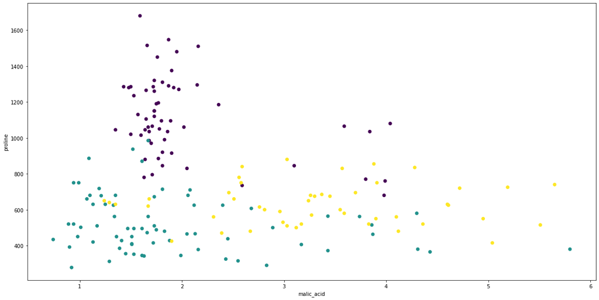

```python
plt.figure(figsize=(20, 10)) # 讓你的圖看起來大大的
plt.xlabel(wine.feature_names[1], loc = 'center')
plt.ylabel(wine.feature_names[12], loc = 'center')
x = wine.data[:,1]
y = wine.data[:,12]
z = wine.target
plt.scatter(x, y, c = z)
plt.show()
```

#### 簡述為什麼你認為應該要挑選此兩個 feature - 5%

- ans 因為這兩個都是酸！一個是蘋果酸，另一個是脯氨酸，感覺比較有可比較性。

## 有沒有什麼想對助教說的話?

助教好善良 但作業好難：（

[figure not shown]